# Onset data analysis

```r
gene_orphagroup_df = gene_orphagroup_df %>% dplyr::filter(!is.na(gene)) %>% group_by(gene) %>% summarise(orphagroups = as.vector(orphagroup))
```

[output not shown]

# Difference between genes associated with very early onset and late onsets

Very early = antenatal + prenatal + infancy Late = adulthood + elderly

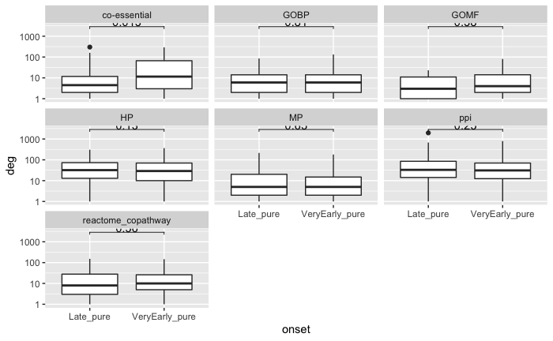

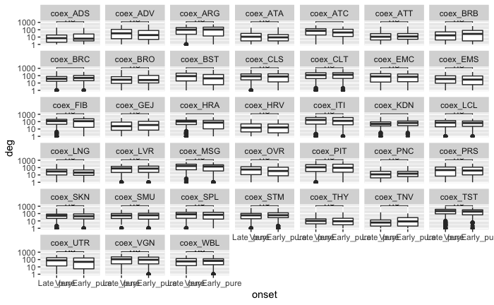

```r
p = ggplot(deg_df_annotate %>% dplyr::filter(grepl("coex", network) & onset %in% onset_of_interest),
           aes(x = onset, y = deg)) +
  geom_boxplot() + facet_wrap(. ~ network) #+ stat_compare_means(comparisons = my_comparisons, method = "wilcox", label = "p.signif") + scale_y_log10()

# make comparison on plot, willcoxon pairwise combination of all onset
my_comparisons = combn(onset_of_interest, 2, simplify = F)
p  + stat_compare_means(comparisons = my_comparisons, method = "wilcox", label = "p.signif") + scale_y_log10()
```

In summary, by separating gene sets to be very early and late does not help with distinguishing properties of essential genes.

# Analysis of the core transcriptional modules

As defined in the manuscript, the core transcriptional module is the network consisting of edges that appear in at least five different tissues.

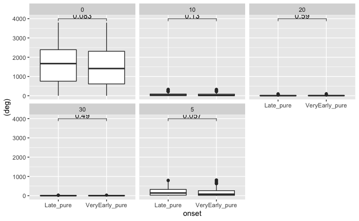

[figure not shown]

## analysis of genes by their earliest onsets

- compute degrees for all the genes
- neighbours that are essential genes
- neighbours that are other disease genes

```r
# add onset groups
gene_network_prop_df = gene_network_prop_df %>%
  mutate(onset_group = factor(onset, labels = c("Early", "Early","Early", "Childhood", "Childhood", "Later", NA, "Later")))
```

[output not shown]

# reproduce the plot

```r
# whether the gene is an essential gene
core_module = core_module %>%
  mutate(essential = gene %in% essential_genes_sym,
         essential_pval= phyper(essential_neighbour-1, essential_genes_in_graph, vcount(g_core_module$`5`)-essential_genes_in_graph, deg,lower.tail= FALSE),
         essential_pval_level = cut(essential_pval, breaks = c(1, 0.05,0.01, 0.001,0.0001, 0), labels = rev(c("ns", "*", "**", "***", "****")) ,include.lowest = T),
         essential_pval_signif = ifelse(essential_pval < 0.05, "significant", "not significant"))



# core modules essential genes
ggplot(core_module %>% mutate(essential = factor(essential, levels = c(T,F), labels = c("essential disease genes", "non-essential disease genes"))),
       aes(x = onset, y = deg)) + scale_y_log10() + ylab("network degree") +
  geom_boxplot()  + facet_wrap(. ~ essential)+ stat_compare_means(comparisons = my_comparisons, method = "wilcox") + ggtitle("Essentiality and onset")
```

[output not shown]

# Onset by disease groups

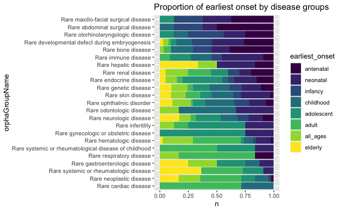

## Link to the number of affected tissues

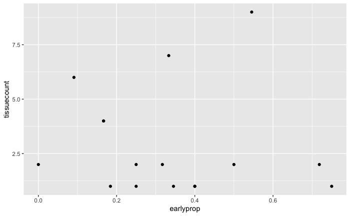

## onset and essentiality

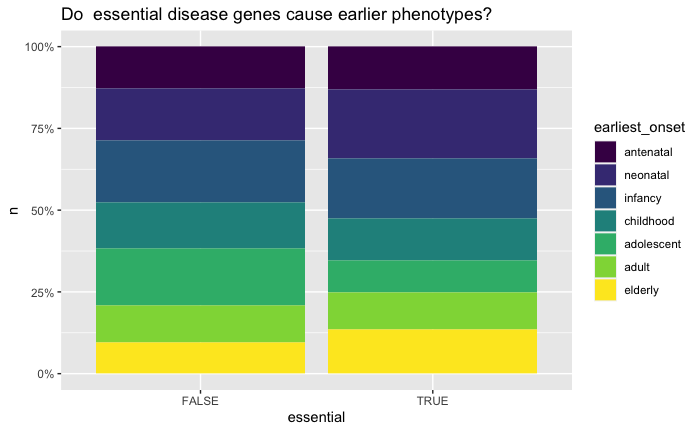

## Do genes with earlier phenotypes affect more systems?

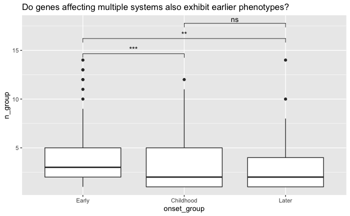

```r
library(ggrepel)
is_outlier <- function(x) {
  return(x < quantile(x, 0.25) - 1.5 * IQR(x) | x > quantile(x, 0.75) + 1.5 * IQR(x))
}

dat = gene_network_prop_df %>% ungroup %>% dplyr::filter(!is.na(earliest_onset), #take only those with onset
                                             earliest_onset != "all_ages", # remove all ages (unclear)
                                             orphagene # take only disease genes
                                             ) %>% distinct(gene, earliest_onset, essential, orphagene, n_group, onset_group) %>%
  group_by(onset_group) %>%
  mutate(outlier = is_outlier(n_group),
         label = ifelse(outlier, gene, ""))


  #%>% count(earliest_onset, essential, orphagene, n_group)

my_comparisons = combn(c("Early", "Childhood", "Later"), 2, simplify = F)

ggplot(dat, aes(x = onset_group, y = n_group)) + geom_boxplot() +
  ggtitle("Do genes affecting multiple systems also exhibit earlier phenotypes?") +
  geom_text_repel(aes(label = label), na.rm = TRUE, hjust = -0.3) +
  stat_compare_means(comparisons = my_comparisons, method = "wilcox", label = "p.signif")
```

## add the essentiality components

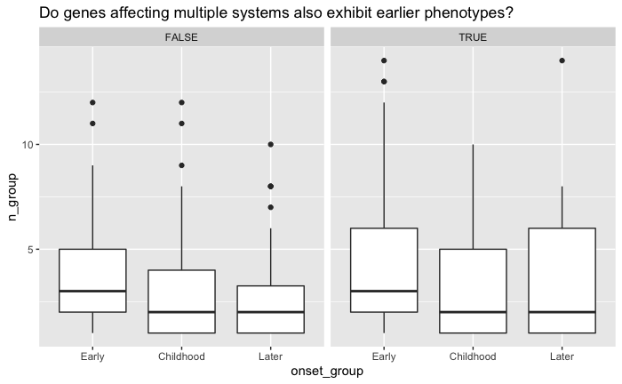

## Disease genes have higher degrees? compared to non disease genes in PPI?

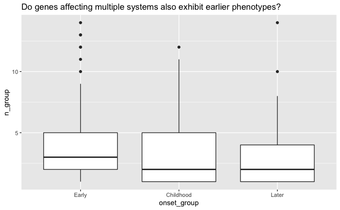

```r
dat = gene_network_prop_df %>% ungroup %>% dplyr::filter(!is.na(earliest_onset), #take only those with onset
                                             earliest_onset != "all_ages", # remove all ages (unclear)
                                             orphagene # take only disease genes
                                             ) %>% distinct(gene, earliest_onset, essential, orphagene, n_group, onset_group)# %>% count(earliest_onset, essential, orphagene, n_group)


ggplot(dat, aes(x = onset_group, y = n_group)) + geom_boxplot() +
  ggtitle("Do genes affecting multiple systems also exhibit earlier phenotypes?")
```

## Network effect:

## Do disease genes connect to other disease genes?

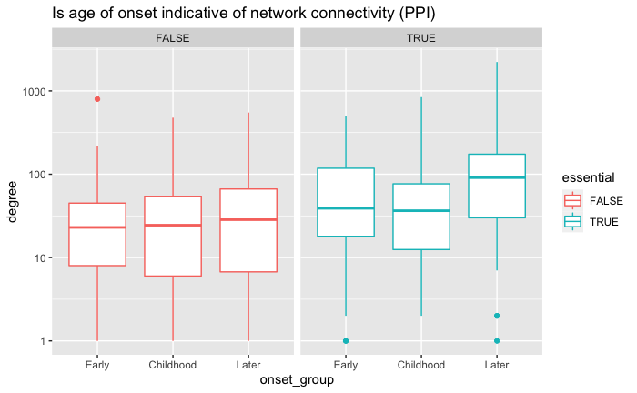

```r
dat = gene_network_prop_df %>% dplyr::filter(network == "ppi", orphagene, !is.na(earliest_onset), earliest_onset != "all_ages")
ggplot(dat, aes(x = onset_group, y = degree, col = essential)) + geom_boxplot()  + scale_y_log10() + facet_wrap(. ~ essential) +
ggtitle(label = "Is age of onset indicative of network connectivity (PPI)")
```

## perform similar analysis but for all networks

```r
pairwise.wilcox.test(dat$degree, dat$onset_group, p.adjust.method="none", paired = F) %>% broom::tidy()
```

```
cannot compute exact p-value with ties
```

| group1 | group2 | p.value |
| --- | --- | --- |
| Childhood | Early | 0.278228383 |
| Later | Early | 0.005002914 |
| Later | Childhood | 0.125077731 |

## plot

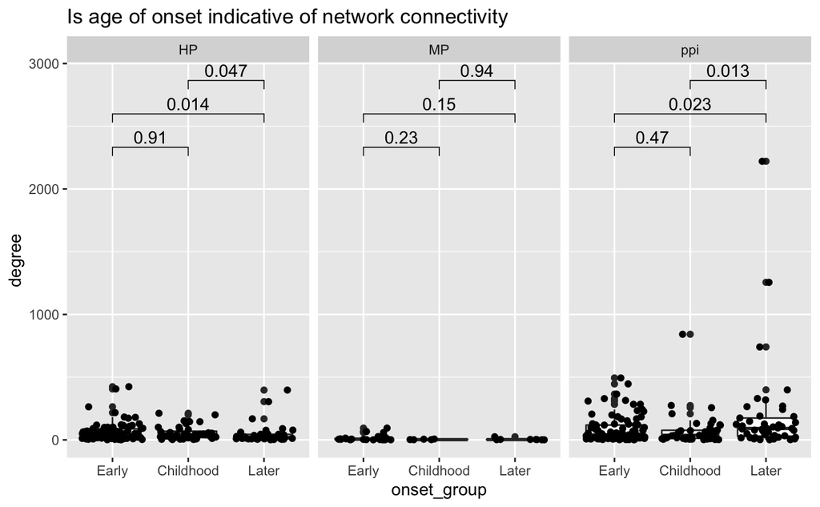

```r
dat = gene_network_prop_df %>% dplyr::filter(network %in% c("MP", "HP", "ppi"), orphagene, !is.na(earliest_onset), earliest_onset != "all_ages", essential)
my_comparisons = combn(c("Early", "Childhood", "Later"), 2, simplify = F)

ggplot(dat, aes(x = onset_group, y = degree)) + geom_boxplot()   + facet_wrap(. ~ network) +
ggtitle(label = "Is age of onset indicative of network connectivity") + geom_jitter(fill = "grey") +
  stat_compare_means(comparisons = my_comparisons, method = "wilcox", paired = F)
```

## Differential enrichments of early/late onset genes

It makes sense that early onset genes are sharing phenotypic similarity than late onset genes. As they may cause substantially severe/multi-systems phenotypes -> thus it shows wider range of phenotypes compared to late onset genes.

On the other hand, essential disease genes for later onset are more well-connected than those in earlier onset? why? - are they connected to each other (like clustered modules, or they’re star-like hubs?) - are they from a few disease groups? -> that cannot really represent anything about diseases?

[figure not shown]

### Transitivity vs degree

| network | node | transitivity |
| --- | --- | --- |
| co-essential | TSC1 | 0.3809524 |
| co-essential | NDUFA8 | 0.8764080 |
| co-essential | ATIC | 0.5464481 |
| co-essential | TADA1 | 0.4093567 |
| co-essential | TADA2B | 0.3789474 |
| co-essential | EARS2 | 0.7515207 |